# Unbiasedness, Identification Assumptions

Shikhar Singh

August 31, 2026

# Agenda

### 1. Unbiasedness

- Difference-in-means (DIM) estimator is unbiased for the true ATE.

### 2. Identification Assumptions

Under what conditions will the DIM estimator give us the right answer? We require **three** assumptions:

- Random Assignment (Recap)
- Excludability
- Non-Interference

### 3. Random Assignment and Selection Bias

How random assignment circumvents the problem of selection bias.

# Unbiasedness

> Let $\theta$ be the parameter we seek to estimate, such as the ATE. $\widehat{\theta}$ is an estimate we get using some estimator. An estimator is unbiased if it, on average, produces an estimate equal to the parameter. That is to say, over many hypothetical experiments, the expected value of the estimator equals the parameter: $\widehat{\theta}$ is unbiased if $\mathbb{E}[\widehat{\theta}] = \theta$.

**Example:** Imagine a population of 4 subjects who have the following potential outcomes. The true ATE ($\theta$) is $-5$. If we assign exactly 2 subjects at random to treatment, there are six possible assignment vectors ($d_1 \cdots d_6$). Here is the science table with the potential outcomes, possible hypothetical experiments, and DIM estimate for each hypothetical experiment.

```r
library(tidyverse)
library(randomizr)
library(knitr)

data1 <- tibble(
         Unit = as.character(c(1:4)),
         Y1 = c(10,8,6,4),
         Y0 = c(15,13,11,9))

declaration <- declare_ra(N = 4, m = 2)
D <- obtain_permutation_matrix(declaration)

data1 <- as.data.frame(data1)
data1$d1 <- D[,1]
data1$d2 <- D[,2]
data1$d3 <- D[,3]
data1$d4 <- D[,4]
data1$d5 <- D[,5]
data1$d6 <- D[,6]

data2 <- data1 %>%
  add_row(
    Unit = "Estimate",
    Y1 = NA_integer_,
    Y0 = NA_integer_,
    d1 = -9,
    d2 = -7,
    d3 = -5,
    d4 = -5,
    d5 = -3,
    d6 = -1
    )

kable(data2, align = 'c', caption = "Unbiasedness")
```

Unbiasedness

| Unit | Y1 | Y0 | d1 | d2 | d3 | d4 | d5 | d6 |
| --- | --- | --- | --- | --- | --- | --- | --- | --- |
| 1 | 10 | 15 | 0 | 0 | 0 | 1 | 1 | 1 |
| 2 | 8 | 13 | 0 | 1 | 1 | 0 | 0 | 1 |
| 3 | 6 | 11 | 1 | 0 | 1 | 0 | 1 | 0 |
| 4 | 4 | 9 | 1 | 1 | 0 | 1 | 0 | 0 |
| Estimate | NA | NA | -9 | -7 | -5 | -5 | -3 | -1 |

The six hypothetical experiments give us six estimates. The average value of these estimates is $\frac{(-9) + (-7) + (-5) + (-5) + (-3) + (-1)}{6} = -5$. In other words, $\mathbb{E}[\widehat{\theta}] = -5 = \theta$.

## Formal Proof

Let the DIM estimator ($\widehat{\theta}$) be:

$\frac{\sum_1^m Y_i}{m} - \frac{\sum_{m+1}^N Y_i}{N-m}$

So,$\mathbb{E}[\widehat{\theta}]$ is:

$\mathbb{E}[\frac{\sum_1^m Y_i}{m} - \frac{\sum_{m+1}^N Y_i}{N-m}]$

Which applying the law of iterated expectations can also be written as:

$\mathbb{E}[\frac{\sum_1^m Y_i}{m}] - \mathbb{E}[\frac{\sum_{m+1}^N Y_i}{N-m}]$

Now note that $\frac{\sum_1^m Y_i}{m}$ is basically

$E[Y_i(1) | d_i = 1]$ (we are using $d_i$, a realized assignment vector, not $D_i$ the random variable)

So the first term can be re-written as:

$\mathbb{E}[E[Y_i(1) | d_i = 1]]$

The expectation operator, $\mathbb{E}[\cdot]$ is basically averaging over all possible assignment vectors. So the above term can also be rewritten as:

$\mathbb{E}[Y_i(1) | D_i = 1]$ (we are now using $D_i$ *not* $d_i$)

So the above expression can be re-written as:

$\mathbb{E}[Y_i(1) | D_i = 1] - \mathbb{E}[Y_i(0) | D_i = 0]$

In the last class we learned how random assignment allows us to say:

$\mathbb{E}[Y_i(1) | D_i = 1] = \mathbb{E}[Y_i(1)]$ (and similarly for the untreated potential outcomes)

As a result:

$\mathbb{E}[Y_i(1) | D_i = 1] - \mathbb{E}[Y_i(0) | D_i = 0] = \mathbb{E}[Y_i(1)] - \mathbb{E}[Y_i(0)]$

# Core Assumptions

> The difference in means is an *unbiased* estimator of the average treatment effect under three assumptions: random assignment, excludability, and non-interference. In this section, I briefly describe each of these assumptions.

## Random Assignment

> Formally, we have: $Y_i(1), Y_i(0),X \perp\!\!\!\perp D_i$

What does this mean? To explain this, I add two rows to the potential outcomes table. These rows report the correlation between potential outcomes and an assignment vector: $\rho(Y_i(1),d)$ and $\rho(Y_i(0),d)$, $\forall d$.

```r
rho1 <- c("r(Y1,d)","","",round(cor(data1$Y1,data1$d1),2),round(cor(data1$Y1,data1$d2),2),round(cor(data1$Y1,data1$d3),2), round(cor(data1$Y1,data1$d4),2),round(cor(data1$Y1,data1$d5),2),round(cor(data1$Y1,data1$d6),2))

rho2 <- c("r(Y0,d)","","",round(cor(data1$Y0,data1$d1),2),round(cor(data1$Y0,data1$d2),2),round(cor(data1$Y0,data1$d3),2), round(cor(data1$Y0,data1$d4),2),round(cor(data1$Y0,data1$d5),2),round(cor(data1$Y0,data1$d6),2))

data1[5,] <- rho1
data1[6,] <- rho2

kable(data1, align = 'c', caption = "Is Treatment Assignment Correlated with POs?")
```

Is Treatment Assignment Correlated with POs?

| Unit | Y1 | Y0 | d1 | d2 | d3 | d4 | d5 | d6 |
| --- | --- | --- | --- | --- | --- | --- | --- | --- |
| 1 | 10 | 15 | 0 | 0 | 0 | 1 | 1 | 1 |
| 2 | 8 | 13 | 0 | 1 | 1 | 0 | 0 | 1 |
| 3 | 6 | 11 | 1 | 0 | 1 | 0 | 1 | 0 |
| 4 | 4 | 9 | 1 | 1 | 0 | 1 | 0 | 0 |
| r(Y1,d) |  |  | -0.89 | -0.45 | 0 | 0 | 0.45 | 0.89 |
| r(Y0,d) |  |  | -0.89 | -0.45 | 0 | 0 | 0.45 | 0.89 |

**Question:** What is the average value of $\rho(Y_i(1),d)$ and $\rho(Y_i(0),d)$

**Answer**: Zero! Which is the implied property of random assignment.

**Question:** Can you provide an intuition for why the correlation between any given assignment vector and treated/untreated potential outcomes is the same?

**Answer**: The mock data that I use assumes a constant treatment effect. So, $Y_1 = Y_0 - 5$. This implies $Var[Y_1] = Var[Y_0 - 5] = Var[Y_0]$, and that $Cov(Y_1,d) = Cov(Y_0-5,d) = Cov(Y_0,d)$

Finally, does $\mathbb{E}[Y_i(1)] = \mathbb{E}[Y_i(1) | D_i = 0] = \mathbb{E}[Y_i(1) | D_i = 1]$?

$\mathbb{E}[Y_i(1)] = \frac{10+8+6+4}{4} = \frac{28}{4} = 7$

$\mathbb{E}[Y_i(1) | D_i = 0] = (\frac{1}{6})(\frac{10+8}{2}) + (\frac{1}{6})(\frac{10+6}{2}) + (\frac{1}{6})(\frac{10+4}{2}) + (\frac{1}{6})(\frac{8+6}{2}) + (\frac{1}{6})(\frac{8+4}{2}) + (\frac{1}{6})(\frac{6+4}{2}) = 7$

$\mathbb{E}[Y_i(1) | D_i = 1] = (\frac{1}{6})(\frac{6+4}{2}) + (\frac{1}{6})(\frac{8+4}{2}) + (\frac{1}{6})(\frac{8+6}{2}) + (\frac{1}{6})(\frac{10+4}{2}) + (\frac{1}{6})(\frac{10+6}{2}) + (\frac{1}{6})(\frac{10+8}{2})$

Which equals: $\frac{1}{6} \times \frac{84}{2} = 7$

This is what random assignment suggests: $E[Y_i(1) | D_i = 0] = E[Y_i(1) | D_i = 1] = E[Y_i(1)]$

**Note:** Correlations tell us whether there is a linear association between two variables. By itself, it is not evidence of statistical independence because two variables might be non-linearly associated.

## Excludability

> Let’s distinguish between $z_i$ (assignment to treatments) and $d_i$ (treatment status).

For example, $z_i = 1$ is someone who has been assigned to the treatment group. $d_i = 1$ is someone who has received treatment. Technically, it is possible to have subjects who are ($z_i=1, d_i=0$) or what is called *failure to treat* (we will delve into this in greater detail later this semester when we discuss non-compliance).

> Formally, excludability implies: $Y_i(z_i,d_i) = Y_i(d_i)$ Potential outcomes respond only to the actual treatment status $d_i$, not the treatment assignment status $z_i$. In other words, $Y_i(z=1,d)= Y_i(z=0,d)$

As Gerber and Green note, “the exclusion restriction breaks down when random assignment sets in motion causes of $Y_i$ other than the treatment $d_i$.

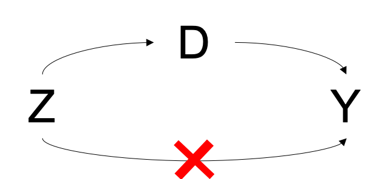

Figure 1: Exclusion Restriction

## Non-Interference

> Non-interference states that subject $i$’s potential outcomes are only affected by the treatment status ($d_i$) and treatment assignment ($z_i$) of $i$, and not the treatment status ($d_j$) or treatment assignment ($z_j$) of any other subject $j \neq i$.

Notationally, non-interference implies:

$$\begin{equation}
Y_i(z,d) = Y_i(z',d')
\end{equation}$$

where $z$ and $z'$ are two different treatment assignment vectors in which $i$’s treatment assignment is the same but some or all other subjects’ treatment assignment is different; similarly, $d$ and $d'$ are two different treatment status vectors in which $i$’s treatment status is the same but some or all other subjects’ treatment status is different. In other words, $z_i = z'_i$ and $d_i=d'_i$.

To illustrate, say we have $n=3$ subjects and we randomly assign one to treatment ($m=1$). Let one assignment vector $z=\{0,1,0\}$ in which person 3 ($i=3$) is untreated. If we assume non-interference, we in effect think that the third person’s potential outcome is the same when the assignment vector is $z'=\{1,0,0\}$. In both $z$ and $z'$, $i$’s assignment status is the same (only the first and second person’s assignment status changes). However, $i$’s potential outcomes are not sensitive to changes in other people’s treatment or assignment status.

**How is non-interference different from excludability?** The non-interference assumption focuses on how interaction between units affects potential outcomes. The excludability assumption pertains to *what we randomly assign* and *whether treatment is the only thing that moves with assignment*.

# Selection Bias

Remember we just saw that random assignment implies treatment assignment is independent of potential outcomes. What happens when treatment assignment is systematically correlated with potential outcomes? In other words, certain “types” of subjects are able to select into or out of treatment groups?

Consider the ATE estimand:

$\mathbb{E}[Y_i(1) | D_i = 1] - \mathbb{E}[Y_i(0) | D_i = 0]$

We can re-write the term by adding and subtracting the term $\mathbb{E}[Y_i(0) | D_i = 1]$:

$\underbrace{\mathbb{E}[Y_i(1) - Y_i(0) | D_i = 1]}_{\text{ATT}} + \underbrace{\mathbb{E}[Y_i(0) | D_i = 1] - \mathbb{E}[Y_i(0) | D_i = 0]}_{\text{Selection Bias: Baseline diff. in treated and untreated units}}$

With random assignment, we ensure: $\mathbb{E}[Y_i(0) | D_i = 1] = \mathbb{E}[Y_i(0) | D_i = 0]$ (this flows from the random assignment statement above).